# Gauss Jordan Elimination

### **NOTES ON STATISTICS, PROBABILITY and MATHEMATICS**

### Gauss Jordan Elimination and Systems of Linear Equations:

A system of linear equations, such as

$$\begin{align}
a_{11}\,x_1\;+\;a_{12}\,x_2\;+\;\cdots\;+\;a_{1n}\,x_n&\;=\;b_1\\[2ex]
a_{21}\,x_1\;+\;a_{22}\,x_2\;+\;\cdots\;+\;a_{2n}\,x_n&\;=\;b_2\\[2ex]
\vdots\\[2ex]
a_{m1}\,x_1\;+\;a_{m2}\,x_2\;+\;\cdots\;+\;a_{mn}\,x_n&\;=\;b_m\\[2ex]
\end{align}$$

can be summarized as $A\,\vec x =\vec b,$ where $A =\left [ a_{ij} \right ]_{i=1,\dots,m\text{ and }j=1,\dots,n}.$

If on the RHS, we have all zeroes, $A\vec x=\vec 0,$ we have the associated **homogeneous** linear system. The original system is **inhomogeneous**.

#### Row operations allowed:

1. Switch rows
2. Add a multiple of one row to another
3. Multiply a row by a constant different to zero.

$$\left[\begin{array}{rrr|r}
1 & 1 & 3 & 1 \\
1 & -1 & -1 & 5 \\
2 & 0 & 2 & 6
\end{array}\right]$$

can be transformed into

$$\left[\begin{array}{rrr|r}
\bbox[5px,border:2px solid red]{1} & 1 & 3 & 1 \\
0 & \bbox[5px,border:2px solid red]{1} & 2 & -2 \\
0 & 0 & 0 & 0
\end{array}\right]$$

which is the matrix in **echelon form** with the ones in the red square being the **pivots**. However, it doesn’t have to have pivots equal to $1,$ they just have to be different than $0.$ Below these pivots there are only zeroes. Pivots move down and to the right.

The **reduced echelon form** $(\text{rref})$ has all pivots as ones, and the entries above pivots are zero (not just below):

$$\left[\begin{array}{rrr|r}
\bbox[5px,border:2px solid red]{1} & 0 & 1 & 3 \\
0 & \bbox[5px,border:2px solid red]{1} & 2 & -2 \\
0 & 0 & 0 & 0
\end{array}\right]$$

The reduced echelon form is unique (not so the echelon form).

Reading the solution in standard form:

$$\begin{align}
1\,x_1 \;+\; 0\,x_2 \;+\; 1\,x_3\;&=\;3 \\[2ex]
0\,x_1 \;+\; 1\,x_2 \;+\; 2\,x_3\;&=\;-2 \\[2ex]
\end{align}$$

Now, $x_1$ and $x_2$ are **pivot variables**, while $x_3$ is a free variable. So we solve for the pivot variables:

$$\begin{align}
x_1 &= 3-x_3 \\[2ex]
x_2 &= -2 -2x_3
\end{align}$$

and the free variable:

$$x_3 = x_3$$

In vector form

$$\vec x =
\begin{bmatrix}x_1\\x_2\\x_3\end{bmatrix}= \begin{bmatrix}3\\-2\\0
\end{bmatrix}+x_3\,\begin{bmatrix}-1\\-2\\1\end{bmatrix}$$

which is the equation for a line (a point plus a direction vector), and is equivalent to a particular solution (the vector $\begin{bmatrix}3\\-2\\0\end{bmatrix}$) plus a general solution. The general solution has the property $A\vec x =\vec 0$, i.e. it is the null space of $A.$

It is worth noting that the dimension of the null space of $A$ is $n-r$ (number of columns minus the rank), which in this case is just $3-2=1.$

#### FINDING BASIS FOR SUBSPACES IN ECHELON AND RREF:

Starting with an example - matrix $A:$

$$A = \begin{bmatrix}
1&-1&2&3&0\\
2&-2&-1&1&5\\
1&-1&1&2&1\\
-1&1&3&2&-5
\end{bmatrix}$$

and augmenting the matrix with “$b$’s”, allows keeping track of elementary row operations:

$$\left[\begin{array}{rrrrr|r}
1&-1&2&3&0&b_1\\
2&-2&-1&1&5&b_2\\
1&-1&1&2&1&b_3\\
-1&1&3&2&-5&b_4
\end{array}\right]$$

We bring out the pivot columns…

$$\left[\begin{array}{rrrrr|r}
1&-1&2&3&0&b_1\\
0&0&-5&-5&5&b_2-2b_1\\
0&0&-1&-1&1&b_3-b_1\\
0&0&5&5&-5&b_4+b_1
\end{array}\right]$$

…changing rows to avoid fractions:

$$\left[\begin{array}{rrrrr|r}
1&-1&2&3&0&b_1\\
0&0&1&1&-1&b_1-b_3\\
0&0&0&0&0&3b_1 +b_2-5b_3\\
0&0&0&0&0&-4b_1+5b_3+b_4
\end{array}\right]$$

and ending with a non-reduced echelon form:

$$\text{ef}(A)=U=\begin{bmatrix}
1&-1&2&3&0\\
0&0&1&1&-1\\
0&0&0&0&0\\
0&0&0&0&0
\end{bmatrix}$$

with the matrix of elementary row operations:

$$E= \begin{bmatrix}
\text{takes first row unaltered:}&1&0&0&0\\
\text{subtacts third row from first:}&1&0&-1&0\\
\text{takes (3 x 1st) + (2nd) - (5 x 3rd)
row:}&3&1&-5&0\\
\text{takes (-4 x 1st) + (5x3rd) + (1x4th):} &-4&0&5&1
\end{bmatrix}$$

Side by side:

$$U\vert E=\left[\begin{array}{rrrrr|rrrr}
1&-1&2&3&0&1&0&0&0\\
0&0&1&1&-1&1&0&-1&0\\
0&0&0&0&0&3&1&-5&0\\
0&0&0&0&0&-4&0&5&1
\end{array}\right]$$

These are the constraint equations:

$$\left\{
\begin{array}{c}
3b_1 +1b_2-5b_3 +0b_4&= 0 \\
-4b_1+0b_2+5b_3+1b_4 &=0
\end{array}
\right.$$
For instance, taking the first column vector of $\vec a_1=\begin{bmatrix}1\\2\\1\\-1\end{bmatrix}$ and carry out the dot product with the first constraint equation, $\begin{bmatrix}3&1&-5&0 \end{bmatrix}\cdot\begin{bmatrix}1\\2\\1\\-1\end{bmatrix}=0.$ Same with the second constraint equation: $\begin{bmatrix}1&2&1&-1\end{bmatrix}\cdot \begin{bmatrix}-4\\0\\5\\1\end{bmatrix}=0.$

The reduced row echelon can be obtained without keeping track of $b$’s, and just to read out the general solution. To get it, we subtract two times the second row from the first:

$$\text{rref}(A)=\begin{bmatrix}
1&-1&0&1&2\\
0&0&1&1&-1\\
0&0&0&0&0\\
0&0&0&0&0
\end{bmatrix}$$

From this rref, the pivot columns are expressed in terms of the free variables, which only depend on themselves, to obtain the general solution, as well as a basis of the null space of $A.$ The combinations of column vectors elementwise in the solution of the homogeneous system of equations can be expressed as

$$\begin{align}
1x_1 - 1x_2 +0x_3+1x_4+2x_5 &=0\\
0x_1 + 0x_2 +1x_3+1x_4-1x_5 &=0\\
\end{align}$$

The pivot columns are $x_1$ and $x_3$, and we want to express every entry in terms of the free variables $x_2, x_4, x_5:$

$$\begin{align}
x_1&=x_2 -x_4-2x_5\\
x_2&=x_2\\
x_3&=-x_4+x_5\\
x_4 &= x_4\\
x_5&=x_5
\end{align}$$

#### NULL SPACE:

The general solution of $A\vec x =\vec 0$ is:

$$\vec x= x_2
\,\begin{bmatrix}1\\1\\0\\0\\0\end{bmatrix}+x_4\,\begin{bmatrix}-1\\0\\-1\\1\\0\end{bmatrix}+x_5\,\begin{bmatrix}-2\\0\\1\\0\\1\end{bmatrix}$$

and the basis of the null space can be read directly from the rref matrix:

$$\text{rref}(A)=\begin{bmatrix}
1&-1&0&1&2\\
0&0&1&1&-1\\
0&0&0&0&0\\
0&0&0&0&0
\end{bmatrix}\to\begin{bmatrix}
\text{pivot}&\text{free}&\text{pivot}&\text{free}&\text{free}\\\bbox[5px,border:2px
solid red]1&\bbox[5px,border:2px solid
magenta]{+1}&0&\bbox[5px,border:2px solid
green]{-1}&\bbox[5px,border:2px solid orange]{-2}\\
0&0&\bbox[5px,border:2px solid red]1&\bbox[5px,border:2px
solid green]{-1}&\bbox[5px,border:2px solid orange]{+1}\\
0&0&0&0&0\\
0&0&0&0&0
\end{bmatrix}$$

the null space has basis vectors with $5$ elements, which will incorporate the magenta elements above:

$$\begin{pmatrix}\begin{bmatrix}0\\1\\0\\0\\0
\end{bmatrix},
\begin{bmatrix}0\\0\\0\\1\\0 \end{bmatrix},\begin{bmatrix}0\\0\\0\\0\\1
\end{bmatrix} \end{pmatrix} \to
\begin{matrix}\text{pivot }\to\\\text{free }\to\\\text{pivot
}\to\\\text{free }\to\\\text{free }\to\\\end{matrix}
\begin{pmatrix}\begin{bmatrix}\bbox[5px,border:2px solid
magenta]{+1}\\1\\0\\0\\0 \end{bmatrix},
\begin{bmatrix}\bbox[5px,border:2px solid
green]{-1}\\0\\\bbox[5px,border:2px solid green]{-1}\\1\\0
\end{bmatrix},\begin{bmatrix}\bbox[5px,border:2px solid
orange]{-2}\\0\\\bbox[5px,border:2px solid orange]{+1}\\0\\1
\end{bmatrix} \end{pmatrix}$$

These vectors are the solution to the homogeneous system of linear equations $A\vec x=\vec 0,$ and span the null space of $A$, plus they are linearly independent. Hence they are a $\color{blue}{\text{basis of the null space}}.$ It has a dimension of $3$, corresponding to the number of free variables. Vectors in the null space of $A$ are orthogonal to the rows of $A$, an express what linear combinations of the columns of $A$ result in $\vec 0.$

**The dimension of the null space $N(A)$ is the number of columns minus the rank: $n-r$.**

#### COLUMN SPACE:

Observe that the column space of $A$ is precisely the span of the column vectors, and also the $\vec b$’s for which the system of linear equations $A\vec x = \vec b$ is **consistent** (i.e. it has one or more solutions):

$$\begin{align}
\text{Col }(A) &=\text{Span }\left(\{\vec a_1, \vec a_2,\dots , \vec
a_n\} \right)\\[2ex]
&=\{\vec b: \; A\,\vec x=\vec b\text{ is consistent}\}
\end{align}$$

and for these equations to be consistent the constraint equations have to hold. Or in other words, if a vector is in the null space of $\vec w\in A^\top$, then $\vec w \vec b = \vec 0.$

**The dimension of the column space $\text{Col}(A)$ is the rank $r$.**

#### ROW SPACE:

A $\color{blue}{\text{basis of the row space}}$ can be found in the **non-zero rows of any echelon form**: $\begin{bmatrix}1&0\\-1&0\\2&1\\3&1\\0&-1\\\end{bmatrix}:$

$$U\vert E=\left[\begin{array}{rrrrr|rrrr}
\bbox[5px,border:2px solid magenta]1&\bbox[5px,border:2px solid
magenta]{-1}&\bbox[5px,border:2px solid
magenta]2&\bbox[5px,border:2px solid
magenta]3&\bbox[5px,border:2px solid
magenta]0&1&0&0&0\\
\bbox[5px,border:2px solid red]0&\bbox[5px,border:2px solid
red]0&\bbox[5px,border:2px solid red]1&\bbox[5px,border:2px
solid red]1&\bbox[5px,border:2px solid
red]{-1}&1&0&-1&0\\
0&0&0&0&0&3&1&-5&0\\
0&0&0&0&0&-4&0&5&1
\end{array}\right]$$

**The dimension of the row space $\text{Row}(A)$ is the rank $r$.**

#### LEFT NULL SPACE:

A $\color{blue}{\text{basis of the null space of the transposed (left null space) }N(A^\top)}$ can be obtained by transposing the bottom rows of $E$

$$U\vert E=\left[\begin{array}{rrrrr|rrrr}
1&-1&2&3&0&1&0&0&0\\
0&0&1&1&-1&1&0&-1&0\\
0&0&0&0&0&\bbox[5px,border:2px solid
magenta]{3}&\bbox[5px,border:2px solid
magenta]1&\bbox[5px,border:2px solid
magenta]{-5}&\bbox[5px,border:2px solid magenta]{0}\\
0&0&0&0&0&\bbox[5px,border:2px solid
red]{-4}&\bbox[5px,border:2px solid red]0&\bbox[5px,border:2px
solid red]5&\bbox[5px,border:2px solid red]1
\end{array}\right]$$

corresponding to the zero rows in the echelon form: $\begin{bmatrix}3&-4\\1&0\\-5&5\\0&1\end{bmatrix}.$ Vectors in the null space of $A^\top$ express what cominations of the rows of $A$ result in $\vec 0.$

Since in the null space of $A^\top$ (the left null space) we are looking at vectors that $A^\top \,y=\vec 0\implies y^\top\,A =\vec 0^\top$, or referring back to the matrix example above, where

$\begin{align} E\,A &=U\\[2ex] \begin{bmatrix}\\ \\ 3&1&-5&0\\-4&0&5&1\end{bmatrix}\;A &=\begin{bmatrix}\\ \\ 0&0&0&0\\0&0&0&0\end{bmatrix} \end{align}$

The components of the null space of $A^\top$ are the coefficients of the constraint equations (above), and are orthogonal to the column vectors of $A$ because for each one of them, a vector in the left null space expresses the combinations of each entry (rows) that result in zero.

**The dimension of the left null space $N(A^\top)$ is the number of rows minus the rank $m-r$.**

Here is a quick geometric illustration with the matrix

$$A = \begin{bmatrix}
1&2&3\\4&5&6\end{bmatrix}$$

which has the rref

$$A = \begin{bmatrix}
1&0&-1\\0&1&2\end{bmatrix}$$

with two pivot columns (leading $1$’s), and with a column and row space of dimension $2$ (the rank), a null space of $n-r=3-2=1$, and a left column space of dimension $m-r=2-2=0.$

A basis of the $N(A)$ is $\left\{ \begin{bmatrix}1\\-2\\1 \end{bmatrix}\right\}$, immediately [culled from the rref.](https://math.stackexchange.com/a/2413194/152225) There is, naturally, no basis for the left null space.

The column space lives in $\mathbb R^2$, whereas the row and null spaces live in $\mathbb R^3:$

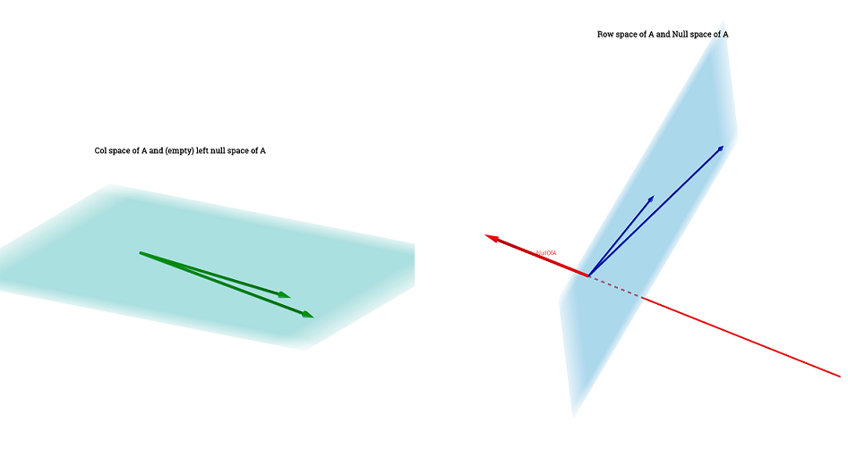

[Home Page](http://rinterested.github.io/statistics/index.html)

**NOTE: These are tentative notes on different topics for personal use - expect mistakes and misunderstandings.**